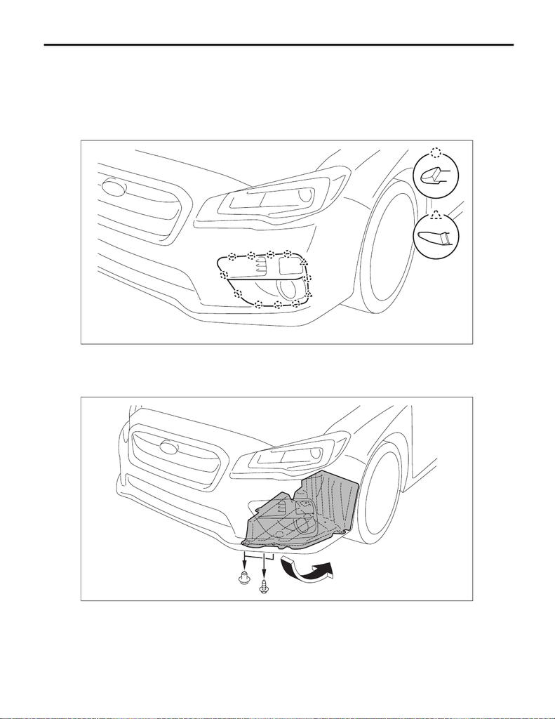

LI-35

Front Turn Signal Light Assembly

LIGHTING SYSTEM

18.Front Turn Signal Light Assembly

A: REMOVAL

1) Disconnect the ground cable from battery. <Ref. to NT-5, BATTERY, NOTE, Note.>

NOTE:

For models other than STI model, disconnect the ground terminal from battery sensor.

2) Release the claws, and then remove the cover - fog light.

NOTE:

If it is hard to remove, push the claw from the back.

3) Lift up the vehicle.

4) Remove the screw and clips, and turn over the front side of the mud guard - front.

LI-01726

LI-01721

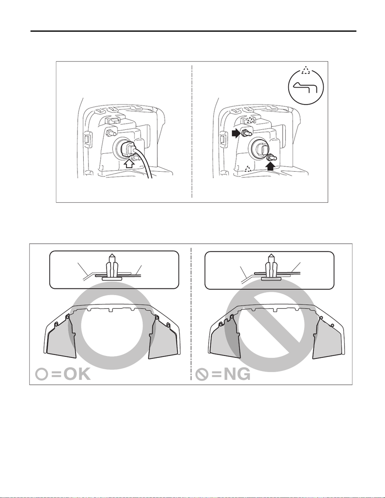

LI-36

Front Turn Signal Light Assembly

LIGHTING SYSTEM

5) Remove the turn signal light assembly - front.

(1) Disconnect the connector.

(2) Remove the nuts and remove the turn signal light assembly - front.

B: INSTALLATION

CAUTION:

front (a).

1) Install the turn signal light assembly - front.

Tightening torque:

7.5 N·m (0.8 kgf-m, 5.5 ft-lb)

2) Install the mud guard - front.

3) Lower the vehicle.

4) Install the cover - fog light.

5) Connect the battery ground terminal. <Ref. to NT-5, BATTERY, NOTE, Note.>

NOTE:

For models other than STI model, connect the ground terminal to battery sensor.

LI-01737

COM00136

(a)

(b)

(a)

(b)

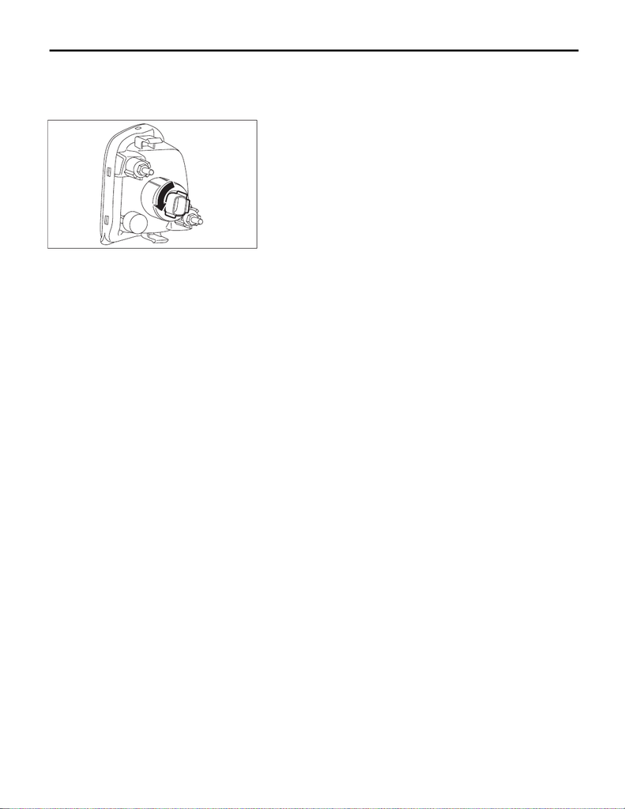

LI-37

Front Turn Signal Light Assembly

LIGHTING SYSTEM

C: DISASSEMBLY

CAUTION:

Use a dry clean cloth so that no grease or water adheres to the glass portion of the bulb.

Rotate the bulb socket in the direction of arrow shown in the figure to remove the front turn signal light bulb.

D: ASSEMBLY

CAUTION:

Use a dry clean cloth so that no grease or water adheres to the glass portion of the bulb.

1) Install the front turn signal light bulb.

2) Install the bulb socket.

LI-01738